# Hechos estilizados

Miguel G.

23/2/2023

# Introducción a los hechos estilizados del rendimiento

Recordemos que un hecho estilizado es una peculiaridad empírica sobre el rendimiento de los activos.

Vamos a ver el comportamiento de un activo para verificar empíricamente los hechos estilizados.

Vamos a utilizar los datos del archivo “ejemplo_rendimiento.xlsx”, el cual contiene el precio y rendimiento diario de las acciones de McDonald’s, en el periodo de 2013 a 2023. La fue de estos datos es Factset.

Iniciamos en análisis de la manera estándar, cargamos datos y manipulación de datos.

```r
rm(list=ls())
setwd("~/Library/CloudStorage/OneDrive-ITESO/01 Documentos/P2023/Analisis riesgo/03 Practicas")
library(PerformanceAnalytics)
library(quantmod)
library(tidyverse)
library(readxl)
library(lubridate)
library(moments)
library(knitr)

activo <- read_excel("ejemplo_rendimiento.xlsx")

activo <- activo %>%
  mutate(date=as.POSIXct( ymd(dmy(date)) ))

rendimiento <- xts(x=activo$rend, order.by = activo$date)

precio <- xts(x=activo$precio, order.by = activo$date)
```

# Hecho estilizado 1

Hecho estilizado 1: Los precios de los activos y el valor de los portafolios siguen una caminata aleatoria.

La siguiente gráfica muestra el comportamiento de los precios:

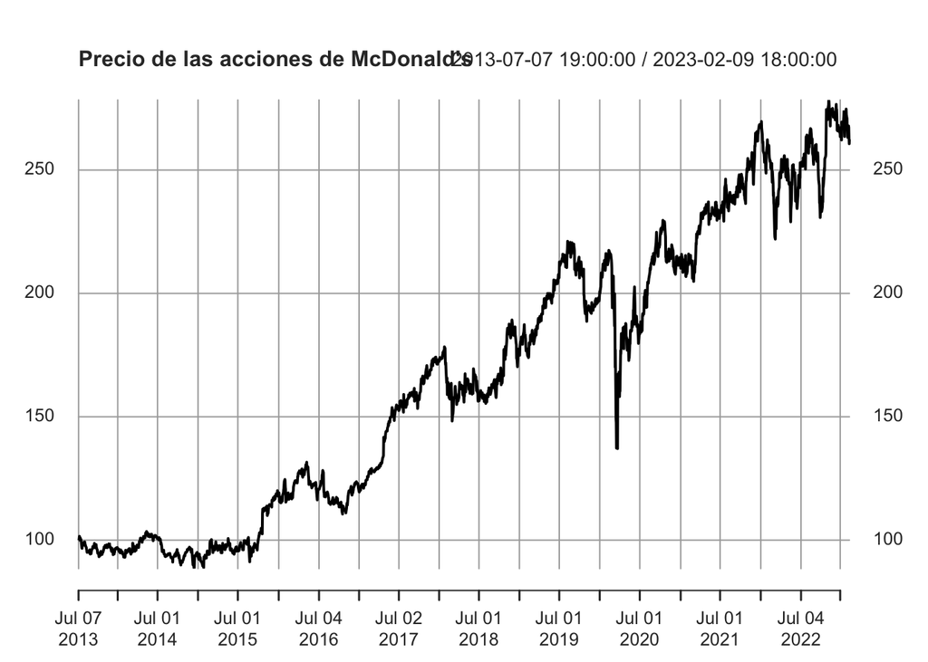

```r
plot(precio, main="Precio de las acciones de McDonald's")
```

El comportamiento errático de una variable aleatoria se describe por medio de un proceso estocástico que se llama *camina aleatoria*. Esto significa que el precio de un activo sigue el siguiente movimiento:

$$S_t=S_{t-1}+\epsilon$$

Donde $E[\epsilon_t]=0$ y $E[\epsilon_t, \epsilon_{t-1}]=Cov[\epsilon_t, \epsilon_{t-1}]=0$ Esto tiene las siguientes implicaciones: * No hay correlación entre los retornos de un periodo con los anteriores. El rendimiento no tiene memoria. * Formación eficiente de los precios, el precio actual de un activo refleja toda la información existente para darle valor, el ajuste de precios ante cambios se lleva a cabo rápidamente.

Anteriormente simulamos procesos estocáticos. Vamos a generar un proceso de Wiener Generalizado para comparar el comportamiento de mi activo contra una simulación:

```r
set.seed(1234)

obs <- 2418
dt <- 1/obs
epsilon <- rnorm(obs, mean = 0, sd=1)

dW <- epsilon*sqrt(dt)

datos <- tibble(
  t=seq(from=dt, to=1, by=dt),
  dW
)

a <- 175
b <- 99

dx <- a*dt+b*dW

X <- 100

X[1] <- X

for(t in 2:obs){
  X[t] <- X[t-1]+dx[t]
}

datos <- mutate(datos, X=X, dX=dx)

cruce <- cbind(datos, activo)

cruce <- cruce %>%
  select(precio, X, date) %>%
  gather("Variable", "Valor", -date)
```

Vamos a graficar ambas variables para observar el comportamiento:

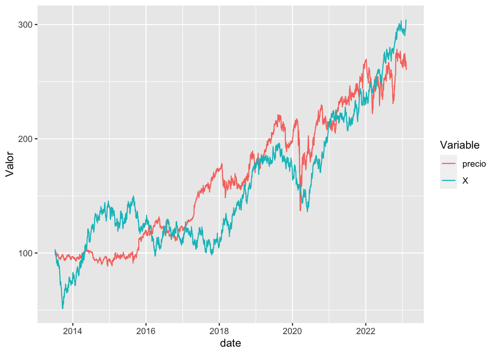

```r
ggplot(cruce, aes(x=date, y=Valor, group=Variable))+
  geom_line(aes(color=Variable))
```

# Hecho estilizado 2

La distribución de los rendimientos es aproximadamente acampanada.

Una característica del rendimiento del precio de los activos, es que si graficamos un histograma, observamos un comportamiento de campana, aunque con ciertas deformaciones. Un comportamiento de campana hace referencia a lo que en estadística se conoce como distribución normal.

La siguiente gráfica muestra un histograma del rendimiento de nuestra acción:

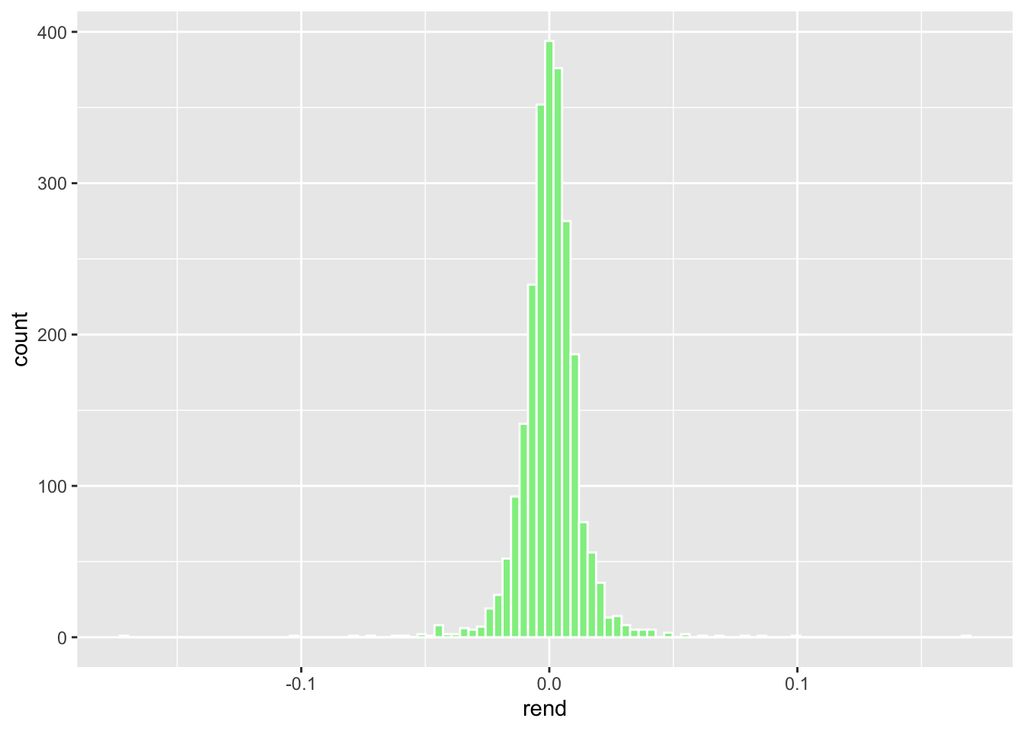

```r
histo_rend <- activo %>%
  ggplot(aes(x=rend))+
  geom_histogram(bins=100, fill="lightgreen", color="white")

histo_rend
```

Como la distribución del precio:

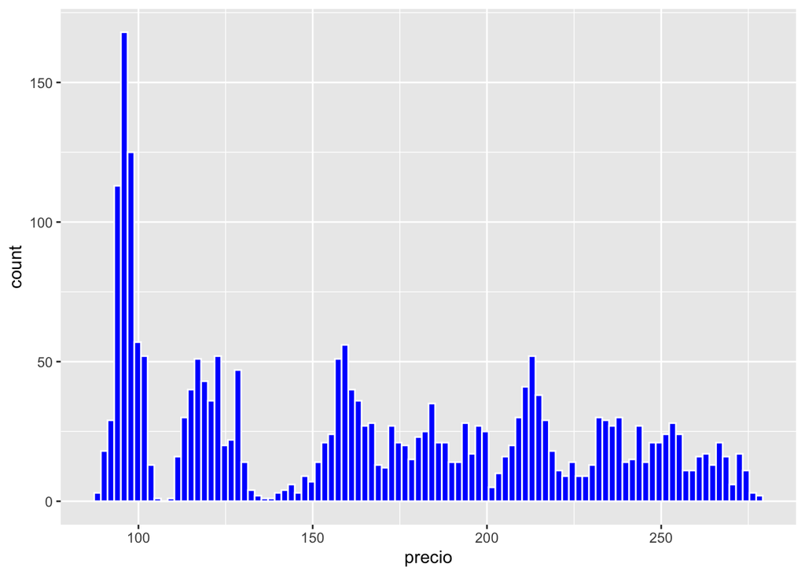

```r
hist_precio <- activo %>%
  ggplot(aes(x=precio))+
  geom_histogram(bins=100, fill="blue", color="white")

hist_precio
```

# Hecho estilizado 3

Los rendimientos de los activos presentan volatilidad no constante y agrupada.

Analizamos las bandas de Bollinger:

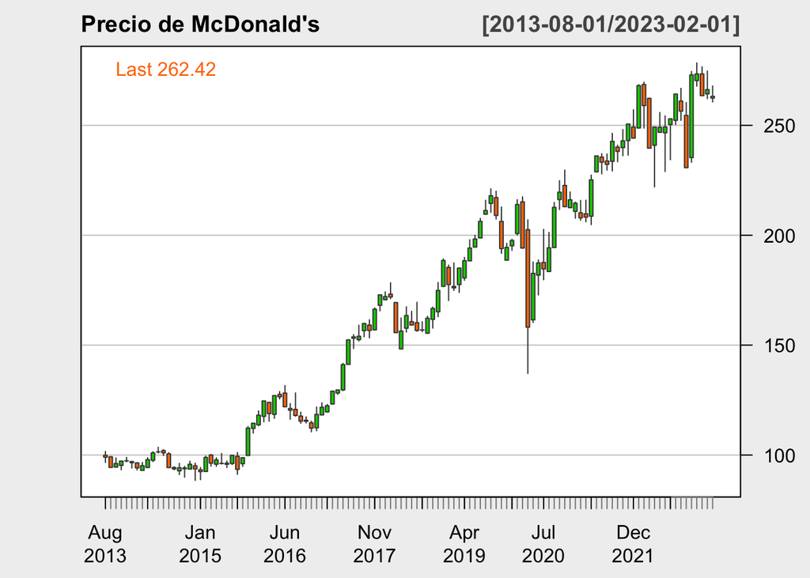

```r
chartSeries(to.monthly(precio), name="Precio de McDonald's", theme="white")
```

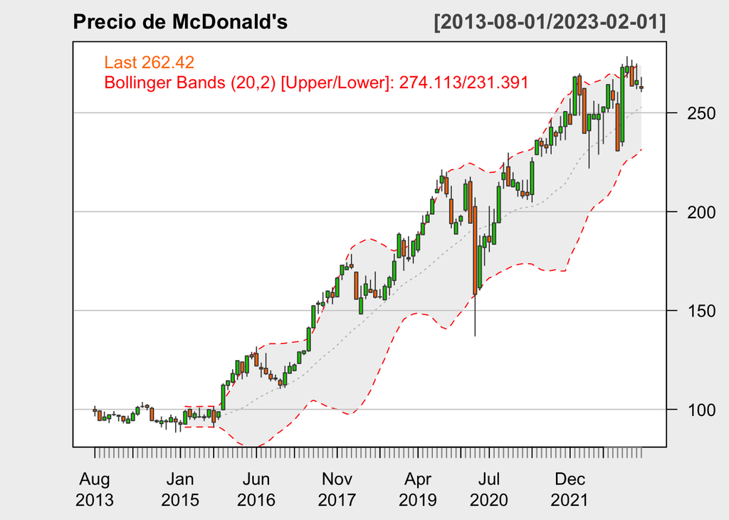

```r
addBBands()
```

Las bandas que se muestran alrededor de la trayectoria del precio son las Bandas de Bollinger y miden la volatilidad del mercado. El 95% del precio deberá situarse dentro de estas bandas, de forma resumida decimos que:

- En un mercado más volátil, las bandas de Bollinger se expanden
- En un mercado menos volátil, las bandas se contraen

# Hecho estilizado 4

La distribución de los rendimientos presenta leptocurtosis.

La distribución de los rendimientos es más *picuda* y de colas pesadas. Esto implica que hay mayores posibilidades de obtener valores más cercanos a la media, que en la distribución normal.

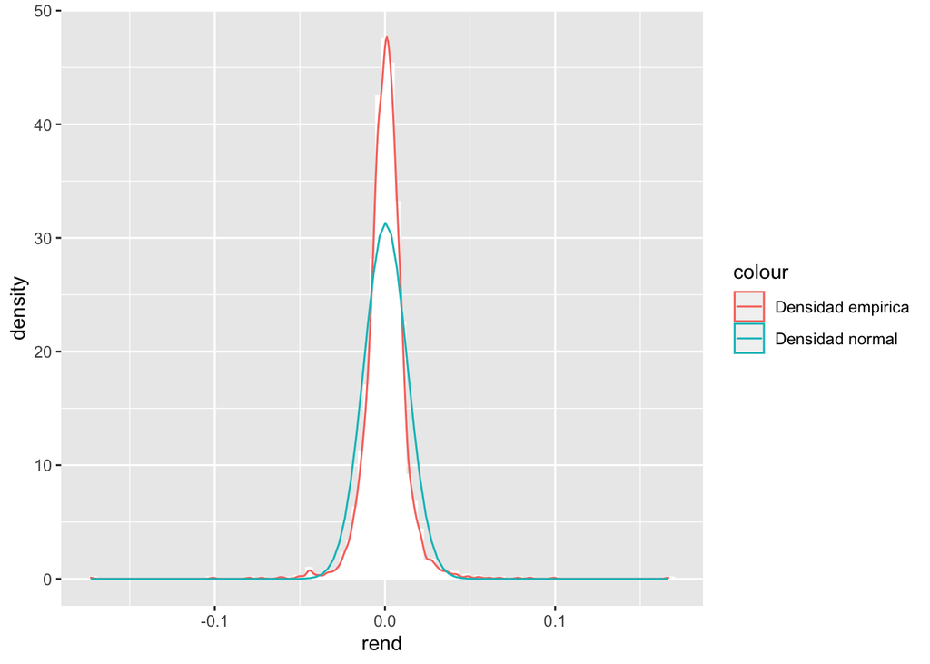

```r
activo %>%
  ggplot(aes(x=rend))+
  geom_histogram(aes(y=..density..) ,bins=100, fill="white", color="white")+
  geom_density(aes(x=rend, col="Densidad empirica"))+
  stat_function(fun=dnorm, args =
                  list(
                    mean=mean(activo$rend),
                    sd=sd(activo$rend)), aes(col="Densidad normal"))
```

# Precio y rendimiento

Anteriormente demostramos que un activo tiene rendimientos que cumplen con los hechos estilizados. Ahora podemos calcular o estimar las características del proceso $dS$, es decir, los parámetros que definen esta ecuación, $\mu$ y $\sigma$, i.e.

$$dS= S_0 \mu dt + S_0 \sigma dW$$
Donde $dW$ es un proceso de wiener: $dW=\epsilon \sqrt{dt}$. Donde ese $\epsilon$ tiene media cero y varianza 1.

Utilizando estos datos podemos verificar que los rendimientos no son normales, y tienen leptocursis. Así como verificar que los precios no son normales.

Anteriormente teníamos las siguientes gráficas:

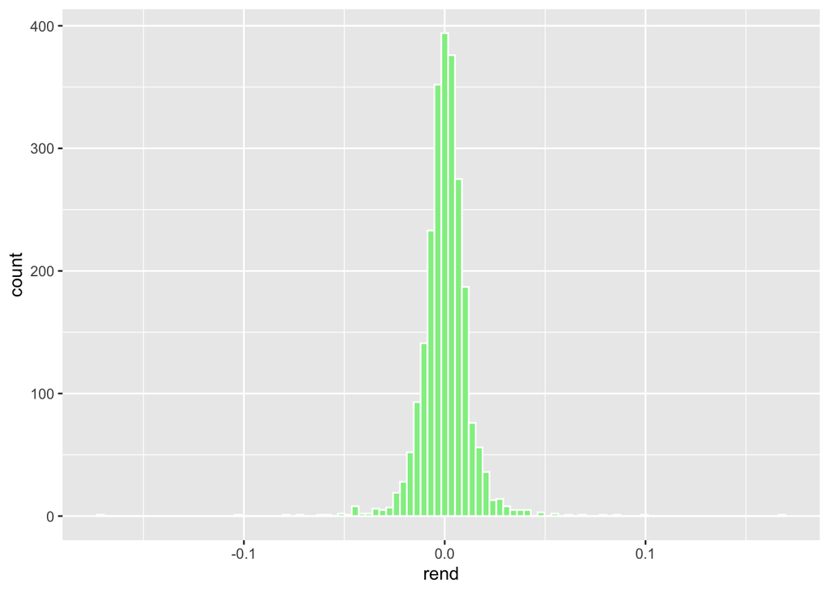

```r
histo_rend
```

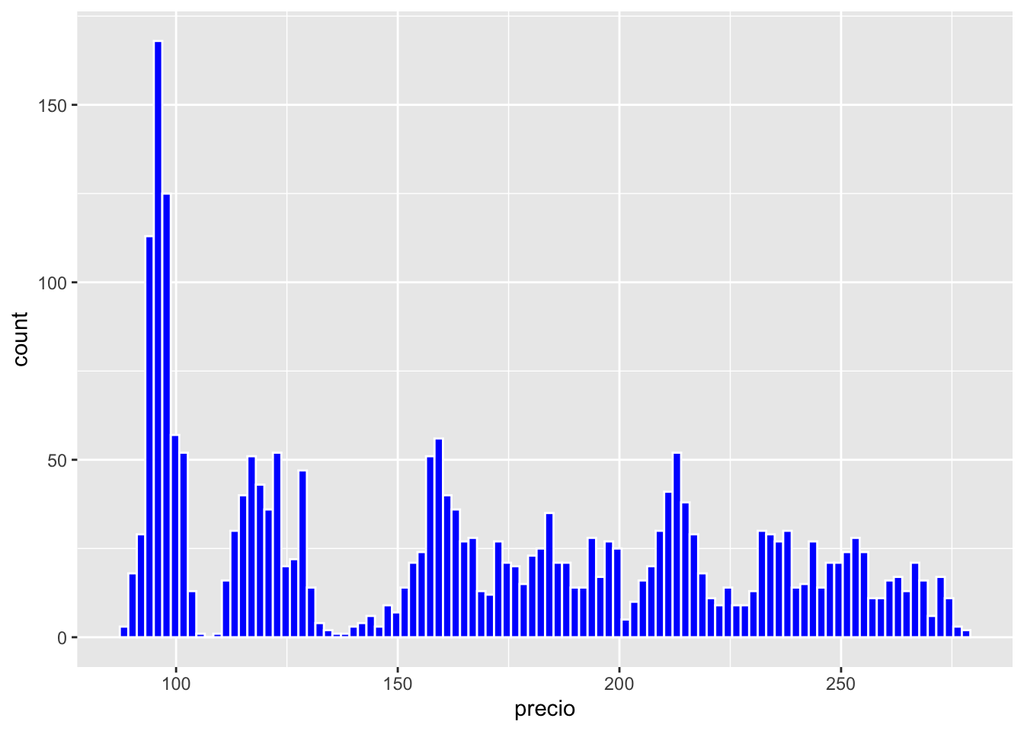

```r
hist_precio
```

Ahora podemos calcular una métrica para determinar si estos datos son normales o no.

En teoría, una variable normal tiene una kurtosis de 3 (o cero dependiendo de la formula) y un coeficiente de asimetria de cero.

Calculamos estos coeficientes para el rendimiento:

- Calculamos la kurtosis:

```r
kurtosis(activo$rend)
```

```
## [1] 35.98165
```

- Coeficiente de asimetria:

```r
skewness(activo$rend)
```

```
## [1] -0.1190326
```

Podemos hacer pruebas de hipótesis formales para determinar si este rendimiento es estadísticamente normal o no.

Existen diferentes pruebas de normalidad:

- Jarque-Bera
- Shapiro-wilk
- D’agostino

Estas pruebas, tiene la misma hipótesis nula:

- $H_0$: La variable es normal (se distribuye normalmente)
- $H_a$: La variable no es normal (no se distribuye normalmente)

Hacemos la prueba jarque-bera al rendimiento

```r
options(scipen=99)
jarque.test(activo$rend)
```

```
##
##  Jarque-Bera Normality Test
##
## data:  activo$rend
## JB = 109600, p-value < 0.00000000000000022
## alternative hypothesis: greater
```

Nota: Si $valor-p<=\alpha$, entonces rechazamos $H_0$ Nota: Si $valor-p>alpha$, entonces No se rechaza $H_0$

Existe evidencia suficiente para rechazar la hipotesis nula de que los rendimientos de este activo son normales, con una significancia del 1% (por lo tanto también al 5% y al 10%).

Tenemos evidencia para que los rendimientos no son normales.

Vamos a calcular ahora las caracteristicas de este rendimiento:

- Media / rendimiento promedio
- Varianza
- Desviación estándar / Volatilidad

```r
estadisticas <- activo %>%
  mutate(año=year(date)) %>%
  group_by(año) %>%
  summarise(
    rend_medio_diario=mean(rend),
    vol_diario=sd(rend),
    rend_medio_anual=mean(rend)*252,
    vol_anual=sd(rend)*252
  )
```

Analizamos al información

```r
kable(estadisticas, digits = 6,
      col.names = c("Año", "Rendimiento medio diario", "Volatilidad diaria",
                    "Rendimiento medio anual", "Volatilidad anual"))
```

| Año | Rendimiento medio diario | Volatilidad diaria | Rendimiento medio anual | Volatilidad anual |
| --- | --- | --- | --- | --- |
| 2013 | -0.000232 | 0.006868 | -0.058425 | 1.730771 |
| 2014 | -0.000139 | 0.007978 | -0.034922 | 2.010493 |
| 2015 | 0.000920 | 0.012021 | 0.231772 | 3.029331 |
| 2016 | 0.000118 | 0.009648 | 0.029853 | 2.431346 |
| 2017 | 0.001380 | 0.008163 | 0.347849 | 2.057016 |
| 2018 | 0.000124 | 0.013062 | 0.031297 | 3.291749 |
| 2019 | 0.000424 | 0.009524 | 0.106930 | 2.400169 |
| 2020 | 0.000326 | 0.025271 | 0.082062 | 6.368177 |
| 2021 | 0.000883 | 0.009734 | 0.222566 | 2.452921 |
| 2022 | -0.000068 | 0.012483 | -0.017149 | 3.145823 |
| 2023 | -0.000151 | 0.012204 | -0.037988 | 3.075516 |

La tabla anterior muestra el rendimiento y volatilidad para cada año. Pero también podemos calcular estos valores históricos (de todo el periodo disponible). Podemos calcular también el rendimiento y volatilidad histórica

```r
historico <- activo %>%
  summarise(
    rend_medio_diario=mean(rend),
    vol_diario=sd(rend))

kable(historico, digits = 6,
      col.names = c("Rendimiento", "Volatilidad diaria"))
```

| Rendimiento | Volatilidad diaria |
| --- | --- |
| 0.0004 | 0.012732 |

Podemos realizar una prueba t, para analizar si los rendimientos son estadísticamente iguales a cero o no.

Realizamos la siguiente prueba:

- $H_0$: $\mu=0$
- $H_0$: $\mu \neq 0$

```r
t.test(activo$rend)
```

```
##
##  One Sample t-test
##
## data:  activo$rend
## t = 1.5433, df = 2417, p-value = 0.1229
## alternative hypothesis: true mean is not equal to 0
## 95 percent confidence interval:
##  -0.0001081408  0.0009072947
## sample estimates:
##   mean of x
## 0.000399577
```

Se concluye que no podemos rechazar Ho

Pero podemos cambiar la alternativa para hacer los otros casos de la prueba t.

Realizamos la siguiente prueba:

- $H_0$: $\mu<=0$
- $H_0$: $\mu > 0$

```r
t.test(activo$rend, alternative = "greater")
```

```
##
##  One Sample t-test
##
## data:  activo$rend
## t = 1.5433, df = 2417, p-value = 0.06145
## alternative hypothesis: true mean is greater than 0
## 95 percent confidence interval:
##  -0.00002646315            Inf
## sample estimates:
##   mean of x
## 0.000399577
```

En este caso, el valor-p es de 0.06, por lo tanto, podemos rechazar Ho, a un nivel de significancia del 10%, pero, no al 5% ni al 1%.

Realizamos la ultima prueba:

- $H_0$: $\mu>=0$
- $H_0$: $\mu < 0$

```r
t.test(activo$rend, alternative = "less")
```

```
##
##  One Sample t-test
##
## data:  activo$rend
## t = 1.5433, df = 2417, p-value = 0.9386
## alternative hypothesis: true mean is less than 0
## 95 percent confidence interval:
##          -Inf 0.0008256171
## sample estimates:
##   mean of x
## 0.000399577
```

## Ecuación de comportamiento

Puedo usar estos valores históricos para estimar mi ecuación de comportamiento $dS$:

$$dS= S_0 \mu dt + S_0 \sigma
dW$$

En este caso:

```r
mu <- historico$rend_medio_diario
sigma <- historico$vol_diario

round(mu, 4)
```

```
## [1] 0.0004
```

```r
round(sigma, 4)
```

```
## [1] 0.0127
```

Reemplazando lo conocido en mi ecuación:

$$dS= S_0 (0.0004) dt + S_0 (0.0127)
\epsilon \sqrt{dt}$$

Vamos asumir que $S_0$ es último precio conocido (más reciente)

```r
S0 <- activo %>%
  filter(date==max(date)) %>%
  select(precio)

S0 <- as.numeric(S0)

S0
```

```
## [1] 262.42
```

Reemplazando lo conocido en mi ecuación:

$$dS= 262.42 (0.0004) dt + 262.42
(0.0127) \epsilon \sqrt{dt}$$

Puedo utilizar esta ecuación para realizar una simulación para los cambios de mañana (dia siguiente):

```r
set.seed(123)
dt <- 1
epsilon <- rnorm(100000, 0, 1)

dS <- S0*mu*dt + S0*sigma*sqrt(dt)*epsilon

head(dS)
```

```
## [1] -1.7677152 -0.6641755  5.3125655  0.3404284  0.5368126  5.8349595
```

Como se comporta dS

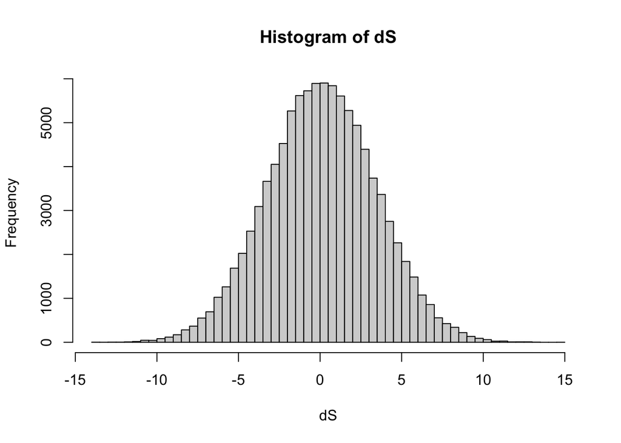

```r
hist(dS, n=100)
```

cuales son sus características (empiricas):

```r
mean(dS)
```

```
## [1] 0.1081203
```

```r
var(dS)
```

```
## [1] 11.1566
```

```r
sd(dS)
```

```
## [1] 3.34015
```

cuales son sus características (teoricas):

```r
#media
mu*S0*dt
```

```
## [1] 0.104857
```

```r
#var
sigma^2*S0^2*dt
```

```
## [1] 11.16256
```

```r
#desv est
sqrt(sigma^2*S0^2*dt)
```

```
## [1] 3.341041
```

cual es precio esperado para mañana (dia siguiente):

```r
pe <- S0+mean(dS)

pe
```

```
## [1] 262.5281
```

cual es el Intervalo de Confianza al 95% para los precios de mañana, recordemos que para un IC al 95%, z=1.96

```r
pe-1.96*sd(dS)
```

```
## [1] 255.9814
```

```r
pe+1.96*sd(dS)
```

```
## [1] 269.0748
```

Podemos utilizar la ecuación del precio para realizar un análisis similar:

$$S_t=S_0 e^{(\mu-0.5\sigma^2)dt+\sigma
dW}$$
Sustituyendo los valores conocidos:

$$S_t=S_0e^{((0.0004)-0.5(0.0127)^2)dt+(0.0127) \sqrt{dt}
\epsilon}$$
Podemos utilizar esta ultima ecuación para realizar simulaciones, o estimaciones del precio para el día de mañana:

```r
dt <- 1
epsilon <- rnorm(100000,0,1)
S <- S0*exp( (mu-0.5*sigma^2)*dt + sigma*sqrt(dt)*epsilon )
```

Cual es el valor esperado del precio para el dia siguiente:

```r
mean(S)
```

```
## [1] 262.5425
```

y Como se distribuye esta simulación, es decir, los posibles precios para el día de mañana:

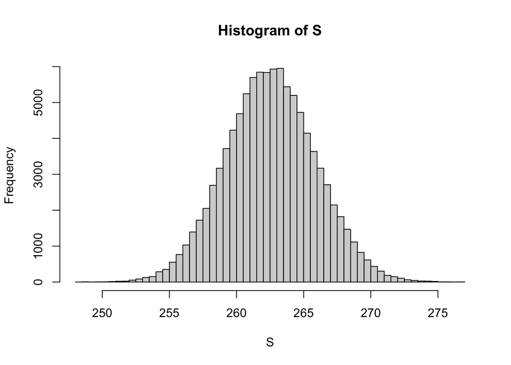

```r
hist(S, n=100)
```

```r
set.seed(123)
nobs <- 1000
dias <- 15
Si <- matrix(0, nobs, dias)

for (j in 1:dias){
  dt <- j
  epsilon <- rnorm(nobs,0,1)
  Sj <- S0*exp( (mu-0.5*sigma^2)*dt + sigma*sqrt(dt)*epsilon )

  Si[,j] <- Sj
}
```

Calculamos los valores esperados para cada dia:

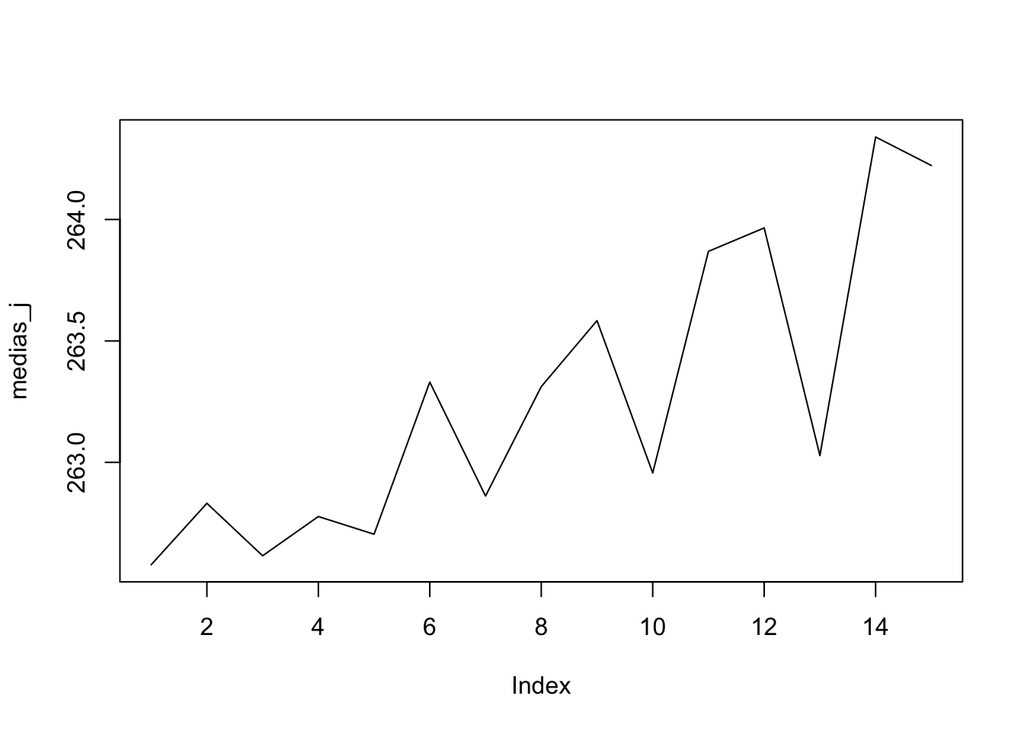

```r
medias_j <- colMeans(Si)

plot(medias_j, type="l")
```

# Descargar datos directo de Yahoo Finance

```r
rm(list=ls())
id <- c("MCD", "WALMEX.MX")
precio <- new.env()
getSymbols(id, env=precio)
```

```
## [1] "MCD"       "WALMEX.MX"
```

```r
activo <- precio[["MCD"]][,6]
names(activo) <- "precio"
```

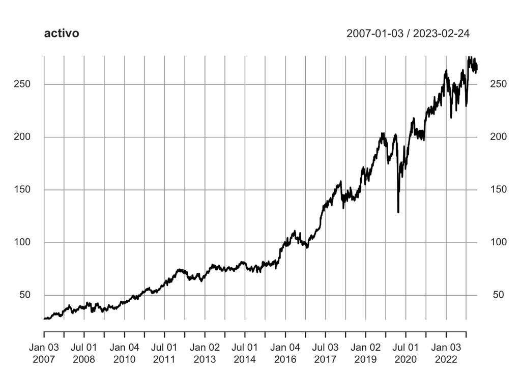

```r
plot(activo)
```

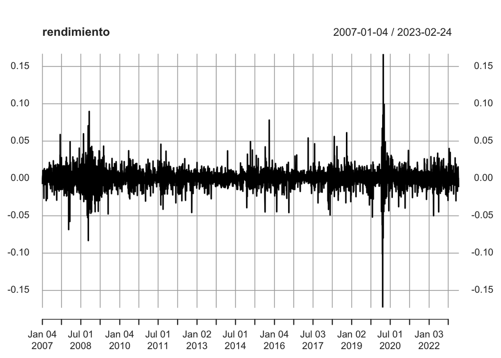

```r
rendimiento <- na.omit( diff (log (activo)) )
plot(rendimiento)
```

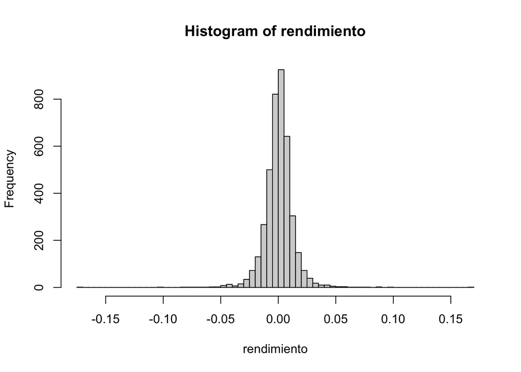

```r
hist(rendimiento, n=100)
```